# individual1-lab3

Cleaning data

```r
data$`Highest year of school completed` <- as.numeric(data$`Highest year of school completed`)
data$`Age of respondent` <- as.numeric(data$`Age of respondent`)
data$`R's age when 1st child born` <- as.numeric(data$`R's age when 1st child born`)
data$`Number of children` <- as.numeric(data$`Number of children`)
data <- data %>% na.omit
```

### Problem 1

```r
data <- rename(data, 'Happiness' = 'General happiness')
data <- rename(data, 'Party' = 'Political party affiliation')
data <- rename(data, 'Income'='Respondents income')
data <- rename(data, 'People'='Number of persons in household')
data <- rename(data, 'Sex' = 'Respondents sex')
data <- rename(data, 'Major' = 'College major 1')
data <- rename(data, 'Education'='Highest year of school completed')
data <- rename(data, 'Parent.age'="R's age when 1st child born")
data <- rename(data, 'Age'='Age of respondent')
data <- rename(data, 'Children'='Number of children')
data <- rename(data, 'Marital.status' = 'Marital status')
data <- rename(data, 'ID' = 'Respondent id number')
data <- rename(data, 'Ballot' = 'Ballot used for interview')
data <- rename(data, 'Year'='Gss year for this respondent')
data <- rename(data, 'Rent' = 'Does r own or rent home?')

#data %>% group_by(Marital.status %>% summarise(count = n(), mean = mean(Education)), )
data %>% group_by(Marital.status) %>% summarise(ed = mean(Education)) %>% arrange(ed)
```

```
## # A tibble: 6 x 2
##   Marital.status    ed
##   <chr>          <dbl>
## 1 Widowed         12.2
## 2 Never married   12.2
## 3 Separated       12.5
## 4 Divorced        13.3
## 5 Married         13.7
## 6 No answer       16
```

Observe the mean years of education arranged in a table by marital status.

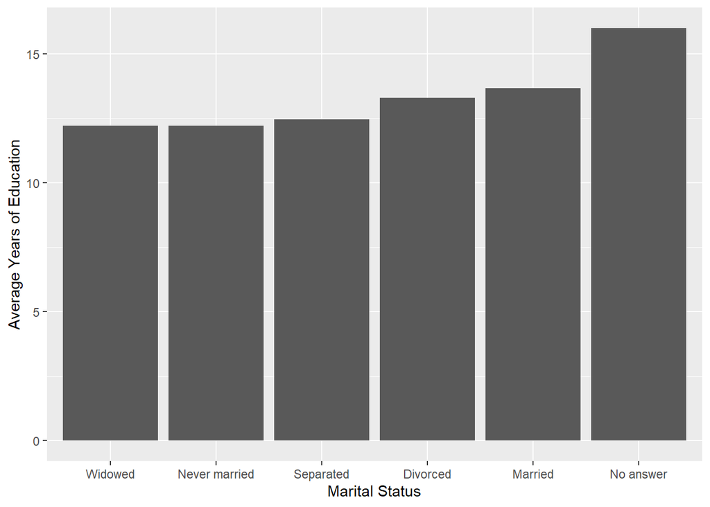

```r
data %>% group_by(Marital.status) %>% summarise(ed = mean(Education)) %>% ggplot(aes(x=reorder(Marital.status, ed), weight=ed))+geom_bar(show.legend = FALSE) + xlab('Marital Status') + ylab('Average Years of Education')
```

We can observe that those who are married had the highest average years of schooling of those who answered. Widowed individuals had the lowest average years of education. Something which can be seen as absurd is that the chart also shows that those with no answer had the highest average schooling,

### Problem 2

```r
frame <- data %>% group_by(Marital.status) %>% filter(Education > mean(Education))
str(frame)
```

```
## grouped_df [10,477 x 15] (S3: grouped_df/tbl_df/tbl/data.frame)
##  $ Year          : num [1:10477] 1994 1994 1994 1994 1994 ...
##  $ Rent          : chr [1:10477] "Own or is buying" "Not applicable" "Own or is buying" "Not applicable" ...
##  $ Happiness     : chr [1:10477] "Very happy" "Very happy" "Very happy" "Not too happy" ...
##  $ Party         : chr [1:10477] "Strong republican" "Strong democrat" "Not str democrat" "Strong democrat" ...
##  $ Income        : chr [1:10477] "$25000 or more" "$25000 or more" "Not applicable" "$25000 or more" ...
##  $ People        : num [1:10477] 1 3 4 1 2 2 4 3 2 1 ...
##  $ Sex           : chr [1:10477] "Male" "Male" "Female" "Male" ...
##  $ Major         : chr [1:10477] "Not applicable" "Not applicable" "Not applicable" "Not applicable" ...
##  $ Education     : num [1:10477] 16 16 16 20 17 13 16 16 17 18 ...
##  $ Parent.age    : num [1:10477] 29 32 34 35 23 20 27 38 20 25 ...
##  $ Age           : num [1:10477] 55 56 39 51 36 58 30 41 25 58 ...
##  $ Children      : num [1:10477] 2 2 2 1 1 4 2 1 1 2 ...
##  $ Marital.status: chr [1:10477] "Married" "Married" "Married" "Separated" ...
##  $ ID            : num [1:10477] 13 14 18 22 30 31 35 41 43 48 ...
##  $ Ballot        : chr [1:10477] "Ballot b" "Ballot c" "Ballot a" "Ballot c" ...
##  - attr(*, "groups")= tibble [6 x 2] (S3: tbl_df/tbl/data.frame)
##   ..$ Marital.status: chr [1:6] "Divorced" "Married" "Never married" "No answer" ...
##   ..$ .rows         : list<int> [1:6]
##   .. ..$ : int [1:1877] 5 22 38 47 49 54 56 63 70 76 ...
##   .. ..$ : int [1:6353] 1 2 3 7 8 11 12 13 14 15 ...
##   .. ..$ : int [1:964] 17 66 79 108 140 179 191 196 207 208 ...
##   .. ..$ : int 5813
##   .. ..$ : int [1:429] 4 9 10 24 52 146 156 157 158 228 ...
##   .. ..$ : int [1:853] 6 41 55 57 58 73 89 104 147 151 ...
##   .. ..@ ptype: int(0)
##   ..- attr(*, ".drop")= logi TRUE
```

```r
library('dplyr')
library('ggplot2')
```

### Problem 3

```r
temp <- data[, c(3, 4, 13)]
marry<- filter(temp, Marital.status == "Married")
non_marry <- filter(temp, Marital.status != "Married")

new_happy <- filter(data, Happiness == "Very happy" | Happiness == "Pretty happy")
new_unhappy <- filter(data, Happiness != "Very happy" & Happiness != "Pretty happy")
```

```r
new_marry = aggregate(marry$Marital.status, by=list(marry$Happiness), FUN=length)
marry_happy <- filter(temp, Marital.status == "Married" & (Happiness == "Very happy" | Happiness == "Pretty happy"))
marry_unhappy <- filter(temp, Marital.status == "Married" & (Happiness != "Very happy" & Happiness != "Pretty happy"))



new_non_marry = aggregate(non_marry$Marital.status, by=list(non_marry$Happiness), FUN=length)
non_marry_happy <- filter(temp, Marital.status != "Married" & (Happiness == "Very happy" | Happiness == "Pretty happy"))
non_marry_unhappy <- filter(temp, Marital.status != "Married" & (Happiness != "Very happy" & Happiness != "Pretty happy"))
```

We can observe that people who are married tend to be happier than people who are not married.

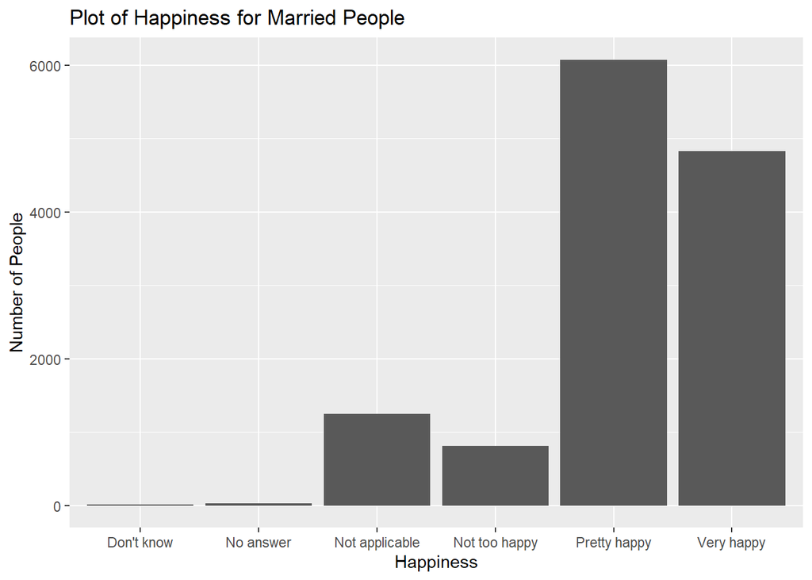

```r
p <- ggplot(new_marry, aes(x = Group.1, weight = x)) + geom_bar()
p + xlab("Happiness") + ylab("Number of People") + ggtitle("Plot of Happiness for Married People")
```

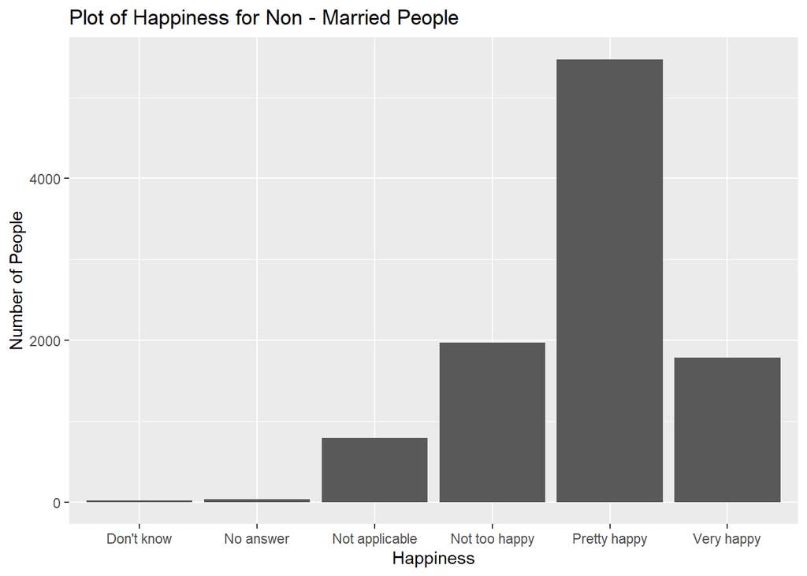

```r
p1 <- ggplot(new_non_marry, aes(x = Group.1, weight = x)) + geom_bar()
p1 + xlab("Happiness") + ylab("Number of People") + ggtitle("Plot of Happiness for Non - Married People")
```

### Problem 4

```r
unique(new_happy$Party)
```

```
##  [1] "Strong democrat"    "Not str democrat"   "Strong republican"
##  [4] "Independent"        "Ind,near dem"       "Not str republican"
##  [7] "Ind,near rep"       "No answer"          "Other party"
## [10] "Don't know"
```

```r
new_indephappy <- new_happy %>%
  group_by(Marital.status) %>%
  filter(Party == "Independent" | Party == "Ind,near rep" | Party == "Ind,near dem")
new_indephappy
```

```
## # A tibble: 6,765 x 15
## # Groups:   Marital.status [6]
##     Year Rent   Happiness  Party  Income People Sex   Major Education Parent.age
##    <dbl> <chr>  <chr>      <chr>  <chr>   <dbl> <chr> <chr>     <dbl>      <dbl>
##  1  1994 Pays ~ Pretty ha~ Indep~ Not a~      1 Fema~ Not ~        12         32
##  2  1994 Pays ~ Pretty ha~ Ind,n~ Not a~      4 Fema~ Not ~        12         20
##  3  1994 Own o~ Very happy Ind,n~ Not a~      3 Fema~ Not ~        16         38
##  4  1994 Not a~ Pretty ha~ Ind,n~ Not a~      1 Fema~ Not ~        12         29
##  5  1994 Not a~ Pretty ha~ Ind,n~ Not a~      2 Male  Not ~        11         24
##  6  1994 Pays ~ Pretty ha~ Ind,n~ Not a~      5 Male  Not ~        10         21
##  7  1994 Not a~ Pretty ha~ Indep~ Not a~      3 Fema~ Not ~        10         19
##  8  1994 Not a~ Pretty ha~ Indep~ Not a~      5 Fema~ Not ~        12         21
##  9  1994 Pays ~ Pretty ha~ Ind,n~ $2500~      4 Male  Not ~        19         32
## 10  1994 Not a~ Pretty ha~ Indep~ Refus~      1 Fema~ Not ~        12         26
## # ... with 6,755 more rows, and 5 more variables: Age <dbl>, Children <dbl>,
## #   Marital.status <chr>, ID <dbl>, Ballot <chr>
```

```r
df1 <- new_indephappy %>%
  summarize(
    total_indephappy=n()
  )
df1
```

```
## # A tibble: 6 x 2
##   Marital.status total_indephappy
##   <chr>                     <int>
## 1 Divorced                   1250
## 2 Married                    3892
## 3 Never married               813
## 4 No answer                     2
## 5 Separated                   290
## 6 Widowed                     518
```

```r
new_indepunhappy <- new_unhappy %>%
  group_by(Marital.status) %>%
  filter(Party == "Independent" | Party == "Ind,near rep" | Party == "Ind,near dem")
new_indepunhappy
```

```
## # A tibble: 1,884 x 15
## # Groups:   Marital.status [5]
##     Year Rent   Happiness  Party  Income People Sex   Major Education Parent.age
##    <dbl> <chr>  <chr>      <chr>  <chr>   <dbl> <chr> <chr>     <dbl>      <dbl>
##  1  1994 Pays ~ Not too h~ Indep~ No an~      3 Fema~ Not ~        12         18
##  2  1994 Own o~ Not too h~ Ind,n~ Not a~      1 Fema~ Not ~        11         32
##  3  1994 Not a~ Not too h~ Ind,n~ $2000~      1 Male  Not ~        16         28
##  4  1994 Pays ~ Not too h~ Ind,n~ $1500~      2 Fema~ Not ~        12         22
##  5  1994 Not a~ Not too h~ Ind,n~ No an~      2 Male  Not ~        14         22
##  6  1994 Not a~ Not too h~ Ind,n~ $2500~      3 Fema~ Not ~        12         19
##  7  1994 Pays ~ Not too h~ Indep~ $2500~      1 Fema~ Not ~        14         19
##  8  1994 Own o~ Not too h~ Indep~ $1000~      5 Male  Not ~        17         26
##  9  1994 Own o~ Not too h~ Ind,n~ $1500~      3 Fema~ Not ~        12         16
## 10  1994 Pays ~ Not too h~ Ind,n~ Not a~      1 Male  Not ~         4         23
## # ... with 1,874 more rows, and 5 more variables: Age <dbl>, Children <dbl>,
## #   Marital.status <chr>, ID <dbl>, Ballot <chr>
```

```r
df2 <- new_indepunhappy %>%
  summarize(
    total_indepunhappy=n()
  )
df2
```

```
## # A tibble: 5 x 2
##   Marital.status total_indepunhappy
##   <chr>                       <int>
## 1 Divorced                      430
## 2 Married                       764
## 3 Never married                 356
## 4 Separated                     151
## 5 Widowed                       183
```

```r
new_rephappy <- new_happy %>%
  group_by(Marital.status) %>%
  filter(Party == "Strong republican" | Party == "Not str republican")
new_indephappy
```

```
## # A tibble: 6,765 x 15
## # Groups:   Marital.status [6]
##     Year Rent   Happiness  Party  Income People Sex   Major Education Parent.age
##    <dbl> <chr>  <chr>      <chr>  <chr>   <dbl> <chr> <chr>     <dbl>      <dbl>
##  1  1994 Pays ~ Pretty ha~ Indep~ Not a~      1 Fema~ Not ~        12         32
##  2  1994 Pays ~ Pretty ha~ Ind,n~ Not a~      4 Fema~ Not ~        12         20
##  3  1994 Own o~ Very happy Ind,n~ Not a~      3 Fema~ Not ~        16         38
##  4  1994 Not a~ Pretty ha~ Ind,n~ Not a~      1 Fema~ Not ~        12         29
##  5  1994 Not a~ Pretty ha~ Ind,n~ Not a~      2 Male  Not ~        11         24
##  6  1994 Pays ~ Pretty ha~ Ind,n~ Not a~      5 Male  Not ~        10         21
##  7  1994 Not a~ Pretty ha~ Indep~ Not a~      3 Fema~ Not ~        10         19
##  8  1994 Not a~ Pretty ha~ Indep~ Not a~      5 Fema~ Not ~        12         21
##  9  1994 Pays ~ Pretty ha~ Ind,n~ $2500~      4 Male  Not ~        19         32
## 10  1994 Not a~ Pretty ha~ Indep~ Refus~      1 Fema~ Not ~        12         26
## # ... with 6,755 more rows, and 5 more variables: Age <dbl>, Children <dbl>,
## #   Marital.status <chr>, ID <dbl>, Ballot <chr>
```

```r
t1 <- new_rephappy %>%
  summarize(
    total_rephappy=n()
  )
t1
```

```
## # A tibble: 5 x 2
##   Marital.status total_rephappy
##   <chr>                   <int>
## 1 Divorced                  724
## 2 Married                  3577
## 3 Never married             163
## 4 Separated                 101
## 5 Widowed                   437
```

```r
new_repunhappy <- new_unhappy %>%
  group_by(Marital.status) %>%
  filter(Party == "Strong republican" | Party == "Not str republican")
new_repunhappy
```

```
## # A tibble: 1,112 x 15
## # Groups:   Marital.status [5]
##     Year Rent   Happiness  Party  Income People Sex   Major Education Parent.age
##    <dbl> <chr>  <chr>      <chr>  <chr>   <dbl> <chr> <chr>     <dbl>      <dbl>
##  1  1994 Not a~ Not too h~ Not s~ Not a~      1 Fema~ Not ~         8         21
##  2  1994 Not a~ Not too h~ Not s~ Not a~      5 Fema~ Not ~        12         24
##  3  1994 Own o~ Not too h~ Not s~ $2500~      3 Male  Not ~        20         39
##  4  1994 Own o~ No answer  Stron~ No an~      2 Male  Not ~        16         28
##  5  1994 Own o~ Not too h~ Stron~ $2500~      3 Male  Not ~        16         24
##  6  1994 Not a~ Not too h~ Not s~ Not a~      3 Male  Not ~        11         22
##  7  1994 Not a~ Not too h~ Stron~ Not a~      2 Fema~ Not ~        12         18
##  8  1994 Own o~ Not too h~ Stron~ $2500~      4 Male  Not ~        13         37
##  9  1994 Not a~ Not too h~ Not s~ $8000~      1 Fema~ Not ~         9         16
## 10  1994 Pays ~ Not too h~ Not s~ $3000~      5 Fema~ Not ~        12         17
## # ... with 1,102 more rows, and 5 more variables: Age <dbl>, Children <dbl>,
## #   Marital.status <chr>, ID <dbl>, Ballot <chr>
```

```r
t2 <- new_repunhappy %>%
  summarize(
    total_repunhappy=n()
  )
t2
```

```
## # A tibble: 5 x 2
##   Marital.status total_repunhappy
##   <chr>                     <int>
## 1 Divorced                    222
## 2 Married                     617
## 3 Never married                61
## 4 Separated                    58
## 5 Widowed                     154
```

```r
new_demhappy <- new_happy %>%
  group_by(Marital.status) %>%
  filter(Party == "Strong democrat" | Party == "Not str democrat")
new_demhappy
```

```
## # A tibble: 5,974 x 15
## # Groups:   Marital.status [6]
##     Year Rent   Happiness  Party  Income People Sex   Major Education Parent.age
##    <dbl> <chr>  <chr>      <chr>  <chr>   <dbl> <chr> <chr>     <dbl>      <dbl>
##  1  1994 Pays ~ Pretty ha~ Stron~ Not a~      6 Fema~ Not ~        12         21
##  2  1994 Pays ~ Very happy Stron~ $1000~      1 Male  Not ~        12         23
##  3  1994 Pays ~ Pretty ha~ Stron~ $1500~      5 Fema~ Not ~        12         17
##  4  1994 Not a~ Pretty ha~ Not s~ $1500~      2 Fema~ Not ~        12         17
##  5  1994 Not a~ Very happy Stron~ $2500~      3 Male  Not ~        16         32
##  6  1994 Own o~ Very happy Not s~ Not a~      4 Fema~ Not ~        16         34
##  7  1994 Pays ~ Pretty ha~ Stron~ $2500~      2 Fema~ Not ~        17         23
##  8  1994 Pays ~ Pretty ha~ Not s~ Not a~      2 Fema~ Not ~        13         20
##  9  1994 Pays ~ Pretty ha~ Not s~ No an~      4 Fema~ Not ~        11         19
## 10  1994 Pays ~ Pretty ha~ Not s~ $1500~      4 Male  Not ~        13         27
## # ... with 5,964 more rows, and 5 more variables: Age <dbl>, Children <dbl>,
## #   Marital.status <chr>, ID <dbl>, Ballot <chr>
```

```r
t3 <- new_demhappy %>%
  summarize(
    total_demhappy=n()
  )
t3
```

```
## # A tibble: 6 x 2
##   Marital.status total_demhappy
##   <chr>                   <int>
## 1 Divorced                 1127
## 2 Married                  3177
## 3 Never married             714
## 4 No answer                   1
## 5 Separated                 234
## 6 Widowed                   721
```

```r
new_demunhappy <- new_unhappy %>%
  group_by(Marital.status) %>%
  filter(Party == "Strong democrat" | Party == "Not str democrat")
new_demunhappy
```

```
## # A tibble: 1,790 x 15
## # Groups:   Marital.status [5]
##     Year Rent   Happiness  Party  Income People Sex   Major Education Parent.age
##    <dbl> <chr>  <chr>      <chr>  <chr>   <dbl> <chr> <chr>     <dbl>      <dbl>
##  1  1994 Own o~ Not too h~ Not s~ $1500~      2 Male  Not ~         8         23
##  2  1994 Pays ~ Not too h~ Stron~ $2000~      4 Fema~ Not ~         9         17
##  3  1994 Not a~ Not too h~ Stron~ $2500~      1 Male  Not ~        20         35
##  4  1994 Pays ~ Not too h~ Not s~ Not a~      4 Fema~ Not ~        16         27
##  5  1994 Pays ~ Not too h~ Stron~ Not a~      1 Male  Not ~        18         25
##  6  1994 Not a~ Not too h~ Stron~ Not a~      1 Fema~ Not ~        12         19
##  7  1994 Own o~ Not too h~ Stron~ Not a~      2 Fema~ Not ~        12         20
##  8  1994 Not a~ Not too h~ Not s~ $2000~      4 Fema~ Not ~         9         20
##  9  1994 Pays ~ Not too h~ Not s~ Not a~      3 Fema~ Not ~        17         23
## 10  1994 Not a~ Not too h~ Not s~ $2500~      2 Fema~ Not ~        12         19
## # ... with 1,780 more rows, and 5 more variables: Age <dbl>, Children <dbl>,
## #   Marital.status <chr>, ID <dbl>, Ballot <chr>
```

```r
t4 <- new_demunhappy %>%
  summarize(
    total_demunhappy=n()
  )
t4
```

```
## # A tibble: 5 x 2
##   Marital.status total_demunhappy
##   <chr>                     <int>
## 1 Divorced                    441
## 2 Married                     667
## 3 Never married               282
## 4 Separated                   118
## 5 Widowed                     282
```

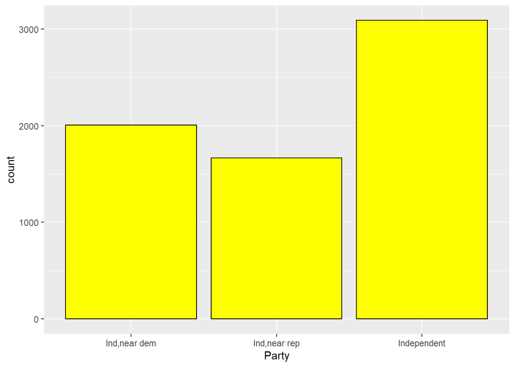

```r
ggplot(new_indephappy, aes(x=Party)) + geom_bar(color="black", fill="yellow")
```

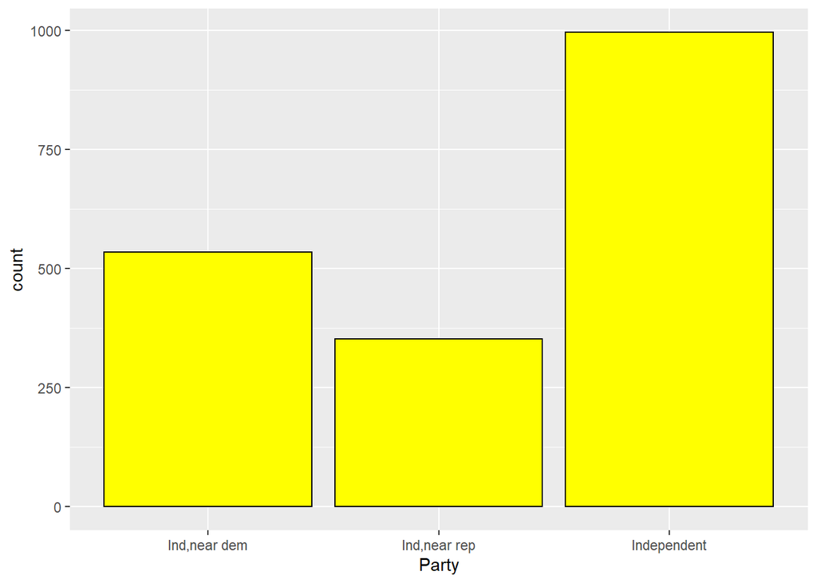

```r
ggplot(new_indepunhappy, aes(x=Party)) + geom_bar(color="black", fill="yellow")
```

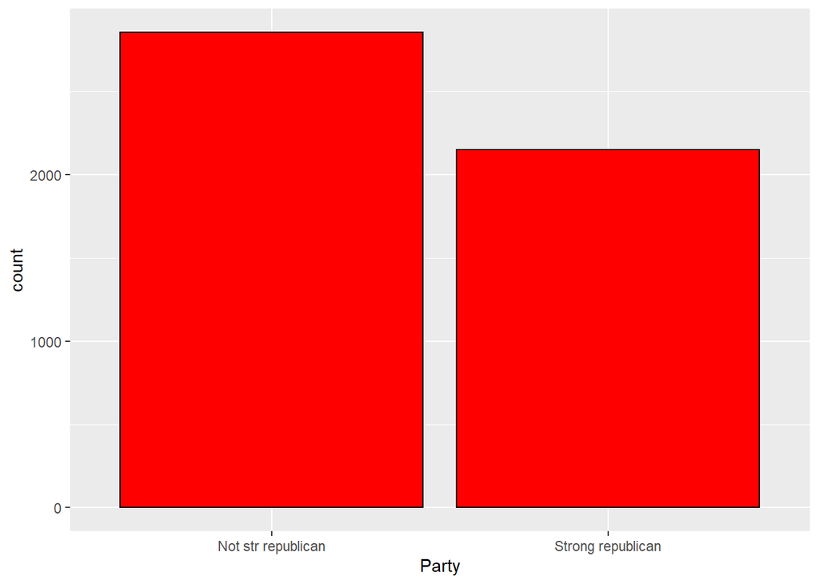

```r
ggplot(new_rephappy, aes(x=Party)) + geom_bar(color="black", fill="red")
```

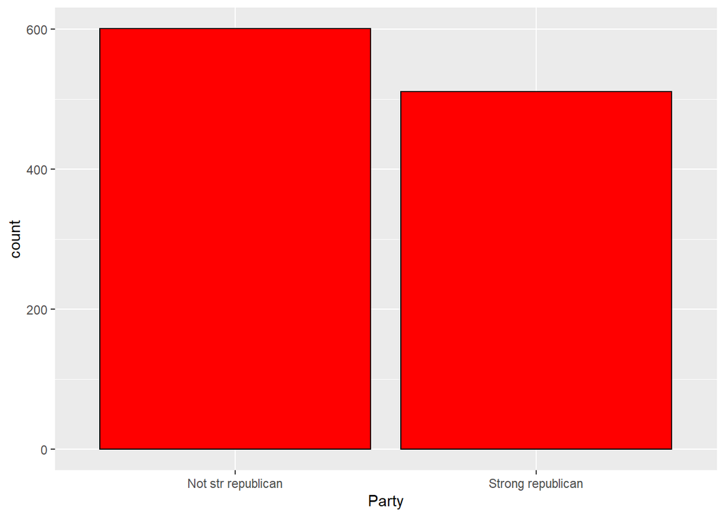

```r
ggplot(new_repunhappy, aes(x=Party)) + geom_bar(color="black", fill="red")
```

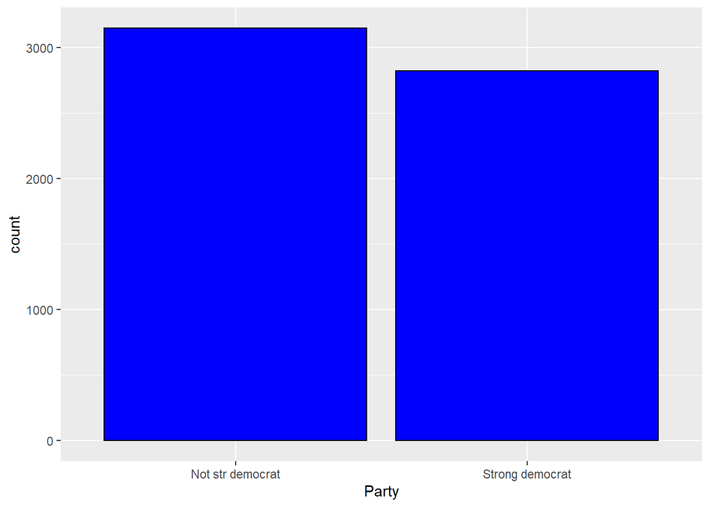

```r
ggplot(new_demhappy, aes(x=Party)) + geom_bar(color="black", fill="blue")
```

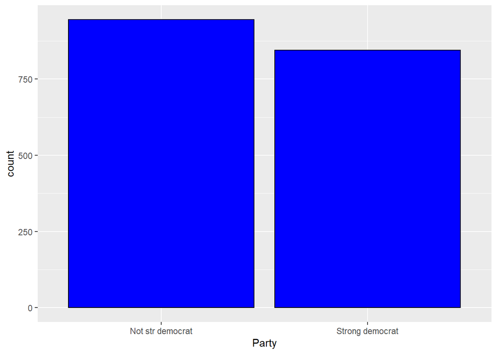

```r
ggplot(new_demunhappy, aes(x=Party)) + geom_bar(color="black", fill="blue")
```

We can observe that party doesn’t affect the relationship we found in the last question. Overall, there tend to be more happy people than unhappy people.

### Problem 5

#### Find out how income affects the ownership of an individual’s home (i.e. owns or rents).

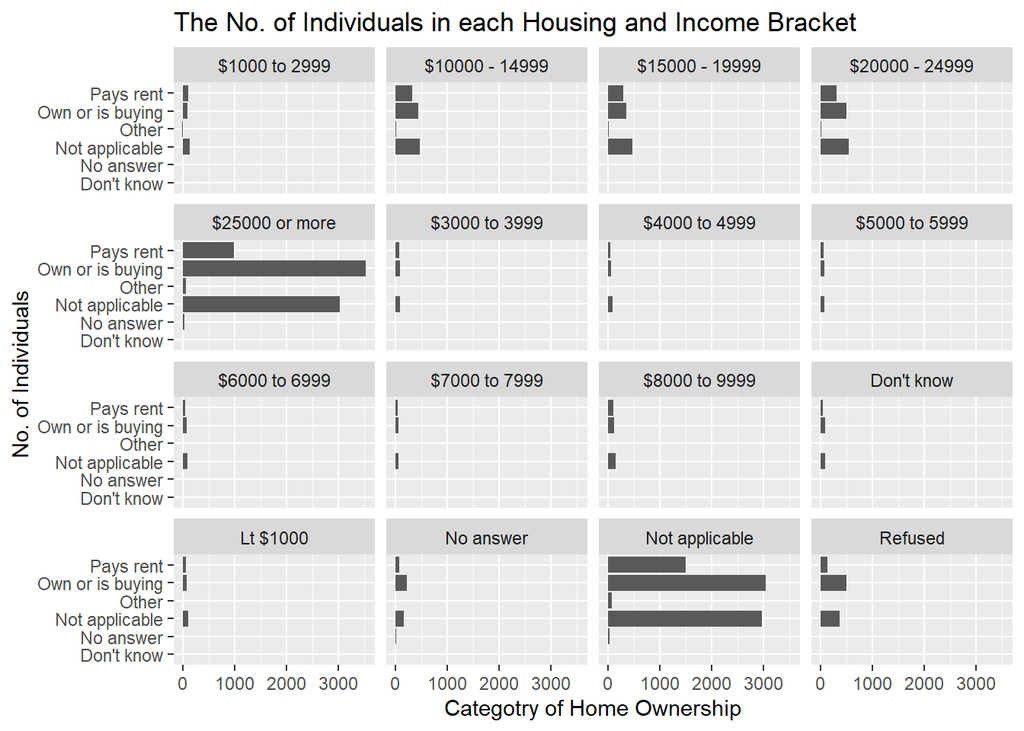

```r
ggplot(data, aes(x = Rent)) + geom_bar() + coord_flip() + facet_wrap( ~ Income) + xlab('No. of Individuals') + ylab('Categotry of Home Ownership') + ggtitle('The No. of Individuals in each Housing and Income Bracket')
```